# Regional Influences towards COVID Vaccinations

Author: Mateos O'Connor

# Introduction

Although faced with the COVID-19 pandemic and its variants, the necessity to receive vaccinations have become increasingly important. That being said, there are those who believe that what the CDC is giving out could be harmful for them and their loved ones. In addition, there is already a small population that is against vaccinations entirely. For any disease, the biggest risk factor is others that aren't immunized. By analyzing the trend for 2021, we should be able to not just observe the different regions of the United States that present an issue during this pandemic, but we can notice the future trend for national cases if vaccinations are still being resisted.

In this project, I will first observe the vaccination trends of each region, and analyze the correlation between the number of cases and these different regions.

# Data Collection and Tidying

```python
#imports
import pandas as pd
import matplotlib.pyplot as plt
import numpy as np
import datetime
from scipy import stats
import statsmodels.formula.api as smf
import seaborn as sns
```

The most important library I will be using is Pandas, which will allow me to access each cell of the multiple sets I will be using. This also allows me to merge these tables, so that I can have all the information I need in one place.

The other important library in my project is Matplotlib, which allows me to visualize the table I end up creating with Pandas. This will allow me to present the trends I find with COVID-19 Cases, according to Region/State.

```python
data = pd.read_csv("https://raw.githubusercontent.com/oconnorm19/COVID-Analysis/main/US_Cases_and_Deaths_By_State.csv")
vax_data = pd.read_csv("https://raw.githubusercontent.com/owid/covid-19-data/master/public/data/vaccinations/us_state_vaccinations.csv")
pop_data = pd.read_csv("https://raw.githubusercontent.com/oconnorm19/COVID-Analysis/main/total_population_v2.csv")

data
```

|  | submission_date | state | tot_cases | conf_cases | prob_cases | new_case | pnew_case | tot_death | conf_death | prob_death | new_death | pnew_death | created_at | consent_cases | consent_deaths |
| --- | --- | --- | --- | --- | --- | --- | --- | --- | --- | --- | --- | --- | --- | --- | --- |
| 0 | 1/22/2020 | AK | 0 | NaN | NaN | 0.0 | NaN | 0 | NaN | NaN | 0.0 | NaN | 3/26/2020 16:22 | NaN | NaN |
| 1 | 1/23/2020 | AK | 0 | NaN | NaN | 0.0 | NaN | 0 | NaN | NaN | 0.0 | NaN | 3/26/2020 16:22 | NaN | NaN |
| 2 | 1/24/2020 | AK | 0 | NaN | NaN | 0.0 | NaN | 0 | NaN | NaN | 0.0 | NaN | 3/26/2020 16:22 | NaN | NaN |
| 3 | 1/25/2020 | AK | 0 | NaN | NaN | 0.0 | NaN | 0 | NaN | NaN | 0.0 | NaN | 3/26/2020 16:22 | NaN | NaN |
| 4 | 1/26/2020 | AK | 0 | NaN | NaN | 0.0 | NaN | 0 | NaN | NaN | 0.0 | NaN | 3/26/2020 16:22 | NaN | NaN |
| ... | ... | ... | ... | ... | ... | ... | ... | ... | ... | ... | ... | ... | ... | ... | ... |
| 41755 | 12/13/2021 | WY | 113077 | 89525.0 | 23552.0 | 215.0 | 54.0 | 1472 | 1472.0 | 0.0 | 0.0 | 0.0 | 12/14/2021 14:53 | Agree | Agree |
| 41756 | 12/14/2021 | WY | 113233 | 89628.0 | 23605.0 | 156.0 | 53.0 | 1502 | 1502.0 | 0.0 | 30.0 | 0.0 | 12/15/2021 14:52 | Agree | Agree |
| 41757 | 12/15/2021 | WY | 113359 | 89739.0 | 23620.0 | 126.0 | 15.0 | 1502 | 1502.0 | 0.0 | 0.0 | 0.0 | 12/16/2021 15:10 | Agree | Agree |
| 41758 | 12/16/2021 | WY | 113478 | 89836.0 | 23642.0 | 119.0 | 22.0 | 1502 | 1502.0 | 0.0 | 0.0 | 0.0 | 12/17/2021 14:18 | Agree | Agree |
| 41759 | 12/17/2021 | WY | 113584 | 89914.0 | 23670.0 | 106.0 | 28.0 | 1502 | 1502.0 | 0.0 | 0.0 | 0.0 | 12/18/2021 14:58 | Agree | Agree |

41760 rows × 15 columns

The cell above demonstrates how I obtain the data for this project. I was able to download tables CDC, where I then could then import all of these files to the project, so that I can use it, as well as present to the audience so that they can view and/or use it for their own data.

Most importantly, the table I provided above is what I will be working with the most. This has COVID-19 reports from every state for almost two years, and where we will be able to track the number of cases for this current year.

```python
#the two datasets have different inputs for states
us_state_to_abbrev = {"Alabama": "AL", "Alaska": "AK", "Arizona": "AZ", "Arkansas": "AR", "California": "CA", "Colorado": "CO",
                      "Connecticut": "CT", "Delaware": "DE", "Florida": "FL", "Georgia": "GA", "Hawaii": "HI", "Idaho": "ID",
                      "Illinois": "IL", "Indiana": "IN","Iowa": "IA", "Kansas": "KS", "Kentucky": "KY", "Louisiana": "LA",
                      "Maine": "ME","Maryland": "MD","Massachusetts": "MA","Michigan": "MI","Minnesota": "MN",
                      "Mississippi": "MS","Missouri": "MO","Montana": "MT","Nebraska": "NE","Nevada": "NV",
                      "New Hampshire": "NH","New Jersey": "NJ","New Mexico": "NM","New York": "NY","North Carolina": "NC",
                      "North Dakota": "ND","Ohio": "OH","Oklahoma": "OK","Oregon": "OR","Pennsylvania": "PA",
                      "Rhode Island": "RI","South Carolina": "SC","South Dakota": "SD","Tennessee": "TN","Texas": "TX",
                      "Utah": "UT", "Vermont": "VT","Virginia": "VA","Washington": "WA","West Virginia": "WV",
                      "Wisconsin": "WI", "Wyoming": "WY", "New York State": "NY"
}

# invert the dictionary
abbrev_to_us_state = dict(map(reversed, us_state_to_abbrev.items()))
```

This is a dictionary to switch the written-out term of each state to their respective abbreviation, and vice versa. This was because the different tables I have used had alternating formats in which to list the U.S. States.

```python
data = data.drop(columns=['conf_cases', 'prob_cases', 'new_case', 'pnew_case', 'conf_death',
                          'prob_death', 'new_death', 'pnew_death', 'created_at', 'consent_cases', 'consent_deaths', ])
vax_data = vax_data.drop(columns=['total_vaccinations','total_vaccinations_per_hundred',
                              'people_fully_vaccinated','distributed_per_hundred',
                              'daily_vaccinations_raw','daily_vaccinations','daily_vaccinations_per_million',
                              'share_doses_used'])

pop_data = pop_data.drop(columns=['Census', 'Estimates Base'])
for i in range(0,50):
    pop_data['2019'][i] = int(pop_data['2019'][i].replace(',', ''))
```

With the above cell, I was able to trim the data so that columns that I wouldn't be using would be removed from the table. An example of this would be 'new_case'. Although it would seem like I should keep it in, this columns reports new cases daily, not monthly. Instead, I can just plot the total_cases for each state, and it should provide a clear difference.

```python
dates_for_data = ['1/12/2021', '2/12/2021', '3/12/2021', '4/12/2021', '5/12/2021', '6/12/2021',
                  '7/12/2021', '8/12/2021', '9/12/2021', '10/12/2021', '11/12/2021', '12/12/2021']

df = data.loc[data['submission_date'] == '1/12/2021']

#filter so that each state has only one row for each month
for y in dates_for_data[1:]:
    df2 = data.loc[data['submission_date'] == y]
    df = df.append(df2, ignore_index=True)

#change date so the date matches with the second dataset
for x in dates_for_data:
    temp = pd.to_datetime(x, format="%m/%d/%Y")
    temp = temp.strftime('%Y-%m-%d')
    df = df.replace(to_replace = x, value = temp)

#filter out all locations besides US states (like Puerto Rico)
all_loc = data.state
all_loc = all_loc.unique()
all_loc
for x in all_loc:
    if abbrev_to_us_state.get(x) is None:
        df = df.drop(df.loc[df['state']==x].index)
    else:
        continue
df = df.reset_index()
df = df.drop(columns='index')
```

Above, I have to reformat the date and state abbreviations, so that they match another table I will be joining together. This also makes great use of the dictionary, because it had values other than the 50 states, like Puerto Rico and Cuba. If that key appears, it is taken out of the table so that they are not counted in our Regional comparison.

## Modify Data for Once per Month, Join

```python
dates_for_data = ['2021-01-12', '2021-02-12', '2021-03-12', '2021-04-12', '2021-05-12',
                  '2021-06-12', '2021-07-12', '2021-08-12', '2021-09-12', '2021-10-12', '2021-11-12', '2021-12-12']
vax_df = vax_data.loc[vax_data['date'] == '2021-01-12']

#filter so that each state has only one row for each month
for y in dates_for_data[1:]:
    vax_df2 = vax_data.loc[vax_data['date'] == y]
    vax_df = vax_df.append(vax_df2, ignore_index=True)
    all_loc = vax_data.location

#filter out all locations besides US states (like Puerto Rico)
all_loc = all_loc.unique()
all_loc
for x in all_loc:
    if us_state_to_abbrev.get(x) is None:
        vax_df = vax_df.drop(vax_df.loc[vax_df['location']==x].index)
    else:
        vax_df = vax_df.replace(to_replace = x, value = us_state_to_abbrev.get(x))
vax_df = vax_df.sort_values(by=['date','location'])
vax_df = vax_df.reset_index()
vax_df = vax_df.drop(columns='index')
df = df.join(vax_df, lsuffix='_caller', rsuffix='_other')
df = df.drop(columns=['location', 'date'])

for_join = pop_data['2019']
for x in range(0,11):
    for_join = for_join.append(pop_data['2019'])
for_join = for_join.reset_index()
for_join = for_join.drop(columns='index')
for_join

df = df.join(for_join, lsuffix='_caller', rsuffix='_other')
df
```

|  | submission_date | state | tot_cases | tot_death | total_distributed | people_vaccinated | people_fully_vaccinated_per_hundred | people_vaccinated_per_hundred | 2019 |
| --- | --- | --- | --- | --- | --- | --- | --- | --- | --- |
| 0 | 2021-01-12 | AK | 49152 | 298 | 141600.0 | 22486.0 | 0.74 | 3.07 | 4903185 |
| 1 | 2021-01-12 | AL | 408525 | 8154 | 377025.0 | 70861.0 | 0.15 | 1.45 | 731545 |
| 2 | 2021-01-12 | AR | 259553 | 4121 | 274400.0 | 39357.0 | 0.00 | 1.30 | 7278717 |
| 3 | 2021-01-12 | AZ | 636488 | 10482 | 563025.0 | 95141.0 | 0.11 | 1.31 | 3017804 |
| 4 | 2021-01-12 | CA | 2747288 | 30105 | 3286050.0 | 703540.0 | 0.25 | 1.78 | 39512223 |
| ... | ... | ... | ... | ... | ... | ... | ... | ... | ... |
| 595 | 2021-12-12 | VT | 50910 | 408 | 1359850.0 | 544038.0 | 75.18 | 87.19 | 8535519 |
| 596 | 2021-12-12 | WA | 790412 | 9554 | 14633585.0 | 5639908.0 | 66.54 | 74.06 | 7614893 |
| 597 | 2021-12-12 | WI | 1024094 | 10386 | 9655595.0 | 3899717.0 | 60.89 | 66.98 | 1792147 |
| 598 | 2021-12-12 | WV | 307432 | 5085 | 3431215.0 | 1595581.0 | 70.97 | 89.03 | 5822434 |
| 599 | 2021-12-12 | WY | 112862 | 1472 | 840845.0 | 316311.0 | 46.42 | 54.65 | 578759 |

600 rows × 9 columns

I will start with 1/12/2021, which will also allow me to track the progress relative to this month, December. I could only work on this year, since there were no tested vaccines available for COVID-19 in 2020. This also corresponds with the vaccination data, which we have added to the our data. You can view the doses on the rightmost side of the table.

Since we are going to be comparing the data for each state, we should aim to have only 50 columns(for each state) respective to each month. Therefore, we should have 600 rows(50 states * 12 months)

## Visualization

Now that we have our table, we can now show the current trend throughout the year for the entire nation. I have made a new array to store each month of the year, for the visual graphs. I did not want to present each x-value as a long date, when it is only one instance-per-month

```python
allcases = []
cases_over_time = []
death_over_time = []
total_vax_over_time = []
months = ['Jan','Feb','Mar','Apr','May','Jun','Jul','Aug','Sep','Oct', 'Nov', 'Dec']
terps = df.groupby(['submission_date'])

for x in terps:
    allcases.append(np.nansum(x[1].tot_cases))
    cases_over_time.append(np.nansum(x[1].tot_cases)/1000000)
    death_over_time.append(np.nansum(x[1].tot_death)/1000000)
    total_vax_over_time.append(np.nansum(x[1].people_vaccinated)/1000000)
```

I chose to filter the results, and make the data representative in the millions, to make it easier to view.

## Total Cases throughout 2021

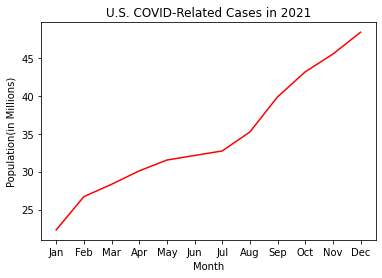

```python
#Total number of cases in the US
plt.title('U.S. COVID-Related Cases in 2021')
plt.xlabel("Month")
plt.ylabel("Population(in Millions)")

plt.plot(months, cases_over_time, color='red')
```

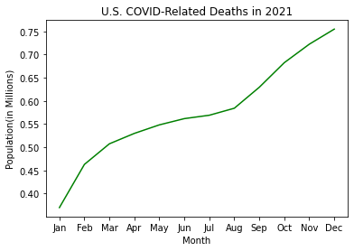

```python
#Total number of reported deaths in the US
plt.title('U.S. COVID-Related Deaths in 2021')
plt.xlabel("Month")
plt.ylabel("Population(in Millions)")
plt.plot(months, death_over_time, color='green')
```

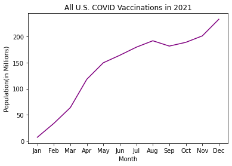

```python
#Total number of Vaccinations in the US
plt.title('All U.S. COVID Vaccinations in 2021')
plt.xlabel("Month")
plt.ylabel("Population(in Millions)")
plt.plot(months, total_vax_over_time, color='purple')
```

All of these graphs can be taken as an estimate, because throughout the data we are given there were states that did not submit their Vaccination Report. An example would be Vermont(VT), which has seven instances of NaN, meaning they did not submit their report for their state.

## Error from Data

```python
state_results = df.groupby(['state'])
state_results.get_group('VT')
```

|  | submission_date | state | tot_cases | tot_death | total_distributed | people_vaccinated | people_fully_vaccinated_per_hundred | people_vaccinated_per_hundred | 2019 |
| --- | --- | --- | --- | --- | --- | --- | --- | --- | --- |
| 45 | 2021-01-12 | VT | 8632 | 161 | 64925.0 | NaN | NaN | NaN | 8535519 |
| 95 | 2021-02-12 | VT | 12460 | 191 | 138025.0 | 68654.0 | 5.00 | 11.00 | 8535519 |
| 145 | 2021-03-12 | VT | 15408 | 212 | 289750.0 | 139766.0 | 11.71 | 22.40 | 8535519 |
| 195 | 2021-04-12 | VT | 19931 | 234 | 515960.0 | 264954.0 | 27.21 | 42.46 | 8535519 |
| 245 | 2021-05-12 | VT | 22118 | 246 | 779270.0 | 391858.0 | 44.39 | 62.80 | 8535519 |
| 295 | 2021-06-12 | VT | 22750 | 249 | 908200.0 | 449320.0 | 60.53 | 72.01 | 8535519 |
| 345 | 2021-07-12 | VT | 22890 | 250 | NaN | NaN | NaN | NaN | 8535519 |
| 395 | 2021-08-12 | VT | 24280 | 256 | 957700.0 | 466518.0 | 66.78 | 74.76 | 8535519 |
| 445 | 2021-09-12 | VT | 28083 | 272 | 1014250.0 | 479143.0 | 68.60 | 76.79 | 8535519 |
| 495 | 2021-10-12 | VT | 33384 | 324 | 1088940.0 | 490176.0 | 70.31 | 78.56 | 8535519 |
| 545 | 2021-11-12 | VT | 40805 | 375 | 1237990.0 | 506558.0 | 71.91 | 81.18 | 8535519 |
| 595 | 2021-12-12 | VT | 50910 | 408 | 1359850.0 | 544038.0 | 75.18 | 87.19 | 8535519 |

I believe that region also has a large part on the number of vaccines per state. This is due to the beliefs and ideals that reflect the environment of each state; there are regions that are hesitant about vaccines in general, therefore impacting the amount of cases, as well as COVID vaccinations.

```python
northeast = ['Connecticut', 'Maine','Massachusetts','New Hampshire','Rhode Island',
             'Vermont','New Jersey','New York','Pennsylvania',]
midwest = ['Illinois', 'Indiana', 'Iowa', 'Kansas', 'Michigan',
           'Minnesota', 'Missouri', 'Nebraska', 'North Dakota',
           'Ohio', 'South Dakota', 'Wisconsin']
south = ['Delaware','Florida','Georgia','Maryland','North Carolina','South Carolina',
         'Virginia','West Virginia','Alabama','Kentucky','Mississippi','Tennessee',
         'Arkansas','Louisiana','Oklahoma','Texas']
west = ['Arizona','Colorado','Idaho','New Mexico','Montana',
        'Utah','Nevada','Wyoming','Alaska','California','Hawaii','Oregon','Washington',]

#get all regions
for x in range(0,len(northeast)):
    northeast[x] = us_state_to_abbrev.get(northeast[x])
for x in range(0,len(midwest)):
    midwest[x] = us_state_to_abbrev.get(midwest[x])
for x in range(0,len(south)):
    south[x] = us_state_to_abbrev.get(south[x])
for x in range(0,len(west)):
    west[x] = us_state_to_abbrev.get(west[x])
```

# Northeast

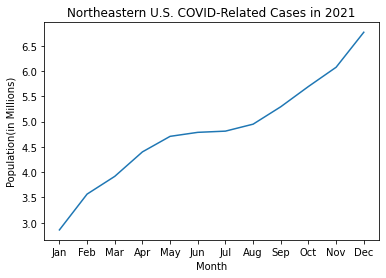

```python
#Total number of reported cases in Northeast
plt.title('Northeastern U.S. COVID-Related Cases in 2021')
plt.xlabel("Month")
plt.ylabel("Population(in Millions)")

all_cases = [0,0,0,0,0,0,0,0,0,0,0,0]

for x in state_results:
    if x[0] in northeast:
        temp = (x[1]['tot_cases']).tolist()
        ne_cases = temp.copy()
        all_cases = np.add(all_cases, temp)
plt.plot(months, all_cases/1000000)
```

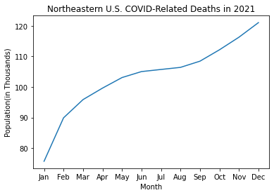

```python
#Total number of reported deaths in Northeast
plt.title('Northeastern U.S. COVID-Related Deaths in 2021')
plt.xlabel("Month")
plt.ylabel("Population(in Thousands)")

all_cases = [0,0,0,0,0,0,0,0,0,0,0,0]

for x in state_results:
    if x[0] in northeast:
        temp = (x[1]['tot_death']).tolist()
        all_cases = np.add(all_cases, temp)
plt.plot(months, all_cases/1000)
```

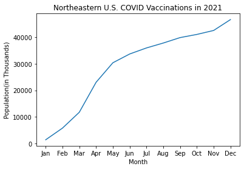

```python
#Total number of reported vaccines in Northeast
plt.title('Northeastern U.S. COVID Vaccinations in 2021')
plt.xlabel("Month")
plt.ylabel("Population(in Thousands)")

all_cases = [0,0,0,0,0,0,0,0,0,0,0,0]

for x in state_results:
    if x[0] in northeast:
        temp = (x[1]['people_vaccinated']).tolist()
        for i in range(0, 12):
            if np.isnan(temp[i]):
                if i != 0:
                    temp[i] = temp[i - 1]
                else:
                    temp[i] = 0.0
        all_cases = np.add(all_cases, temp)
plt.plot(months, all_cases/1000)
```

# Midwest

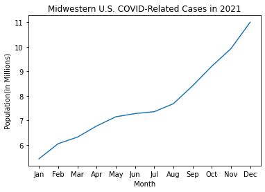

```python
#Total number of reported cases in Midwest
plt.title('Midwestern U.S. COVID-Related Cases in 2021')
plt.xlabel("Month")
plt.ylabel("Population(in Millions)")

all_cases = [0,0,0,0,0,0,0,0,0,0,0,0]

for x in state_results:
    if x[0] in midwest:
        mw_cases = temp.copy()
        temp = (x[1]['tot_cases']).tolist()
        all_cases = np.add(all_cases, temp)
plt.plot(months, all_cases/1000000)
```

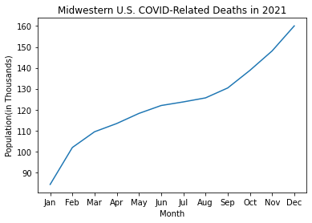

```python
#Total number of reported deaths in Midwest
plt.title('Midwestern U.S. COVID-Related Deaths in 2021')
plt.xlabel("Month")
plt.ylabel("Population(in Thousands)")

all_cases = [0,0,0,0,0,0,0,0,0,0,0,0]

for x in state_results:
    if x[0] in midwest:
        temp = (x[1]['tot_death']).tolist()
        all_cases = np.add(all_cases, temp)
plt.plot(months, all_cases/1000)
```

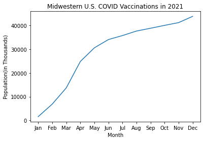

```python
#Total number of reported vaccines in Midwest
plt.title('Midwestern U.S. COVID Vaccinations in 2021')
plt.xlabel("Month")
plt.ylabel("Population(in Thousands)")

all_cases = [0,0,0,0,0,0,0,0,0,0,0,0]

for x in state_results:
    if x[0] in midwest:
        temp = (x[1]['people_vaccinated']).tolist()
        for i in range(0, 12):
            if np.isnan(temp[i]):
                if i != 0:
                    temp[i] = temp[i - 1]
                else:
                    temp[i] = 0.0
        all_cases = np.add(all_cases, temp)
plt.plot(months, all_cases/1000)
```

# South

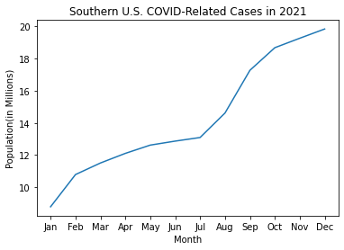

```python
#Total number of reported cases in South
plt.title('Southern U.S. COVID-Related Cases in 2021')
plt.xlabel("Month")
plt.ylabel("Population(in Millions)")

all_cases = [0,0,0,0,0,0,0,0,0,0,0,0]

for x in state_results:
    if x[0] in south:
        so_cases = temp.copy()
        temp = (x[1]['tot_cases']).tolist()
        all_cases = np.add(all_cases, temp)
plt.plot(months, all_cases/1000000)
```

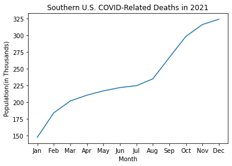

```python
#Total number of reported deaths in South
plt.title('Southern U.S. COVID-Related Deaths in 2021')
plt.xlabel("Month")
plt.ylabel("Population(in Thousands)")

all_cases = [0,0,0,0,0,0,0,0,0,0,0,0]

for x in state_results:
    if x[0] in south:
        temp = (x[1]['tot_death']).tolist()
        all_cases = np.add(all_cases, temp)
plt.plot(months, all_cases/1000)
```

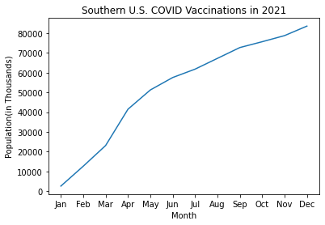

```python
#Total number of reported vaccines in South
plt.title('Southern U.S. COVID Vaccinations in 2021')
plt.xlabel("Month")
plt.ylabel("Population(in Thousands)")

all_cases = [0,0,0,0,0,0,0,0,0,0,0,0]

for x in state_results:
    if x[0] in south:
        temp = (x[1]['people_vaccinated']).tolist()
        for i in range(0, 12):
            if np.isnan(temp[i]):
                if i != 0:
                    temp[i] = temp[i - 1]
                else:
                    temp[i] = 0.0
        all_cases = np.add(all_cases, temp)
plt.plot(months, all_cases/1000)
```

# West

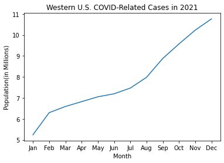

```python
#Total number of reported cases in West
plt.title('Western U.S. COVID-Related Cases in 2021')
plt.xlabel("Month")
plt.ylabel("Population(in Millions)")

all_cases = [0,0,0,0,0,0,0,0,0,0,0,0]

for x in state_results:
    if x[0] in west:
        we_cases = temp.copy()
        temp = (x[1]['tot_cases']).tolist()
        all_cases = np.add(all_cases, temp)
plt.plot(months, all_cases/1000000)
```

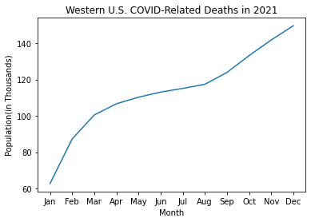

```python
#Total number of reported deaths in West
plt.title('Western U.S. COVID-Related Deaths in 2021')
plt.xlabel("Month")
plt.ylabel("Population(in Thousands)")

all_cases = [0,0,0,0,0,0,0,0,0,0,0,0]

for x in state_results:
    if x[0] in west:
        temp = (x[1]['tot_death']).tolist()
        all_cases = np.add(all_cases, temp)
plt.plot(months, all_cases/1000)
```

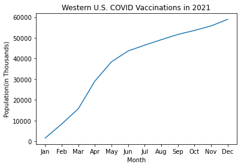

```python
#Total number of reported vaccines in West
plt.title('Western U.S. COVID Vaccinations in 2021')
plt.xlabel("Month")
plt.ylabel("Population(in Thousands)")

all_cases = [0,0,0,0,0,0,0,0,0,0,0,0]

for x in state_results:
    if x[0] in west:
        temp = (x[1]['people_vaccinated']).tolist()
        for i in range(0, 12):
            if np.isnan(temp[i]):
                if i != 0:
                    temp[i] = temp[i - 1]
                else:
                    temp[i] = 0.0
        all_cases = np.add(all_cases, temp)
plt.plot(months, all_cases/1000)
```

# Identifying a Relationship to Region

However, I have predicted that overall vaccinations will have been affected by the different regions throughout the states. While living in Alabama, I found that there was little caution and care towards the pandemic. I found rarely anyone with masks on, and local talk of vaccine fear. However, in places such as the Northeastern region, lockdown steps had been put in place, and masks became mandatory.

Because of this assumption, I believe there will be at least one region that belongs above the regression line, and one that falls, thus dragging down the slope of the regression.

The linear regression that I will be performing will be used to analyze the future trends for COVID-19 cases, given the variables of the month, vaccinated number, and death count. This will allow us to see past what we have, in order to speculate on further action about the problem of vaccination.

```python
lst = []
for i in range(0,12):
    for j in range(0,50):
        lst.append(i)
```

```python
regmod = smf.ols(formula = "tot_cases ~ submission_date + people_vaccinated + tot_death", data = df).fit()
print(regmod.summary())
```

```
                            OLS Regression Results
==============================================================================
Dep. Variable:              tot_cases   R-squared:                       0.965
Model:                            OLS   Adj. R-squared:                  0.964
Method:                 Least Squares   F-statistic:                     1189.
Date:                Mon, 20 Dec 2021   Prob (F-statistic):               0.00
Time:                        23:20:17   Log-Likelihood:                -7739.3
No. Observations:                 580   AIC:                         1.551e+04
Df Residuals:                     566   BIC:                         1.557e+04
Df Model:                          13
Covariance Type:            nonrobust
=================================================================================================
                                    coef    std err          t      P>|t|      [0.025      0.975]
-------------------------------------------------------------------------------------------------
Intercept                       8.28e+04   2.39e+04      3.470      0.001    3.59e+04     1.3e+05
submission_date[T.2021-02-12]  -2.63e+04   3.12e+04     -0.842      0.400   -8.76e+04     3.5e+04
submission_date[T.2021-03-12] -5.735e+04   3.14e+04     -1.824      0.069   -1.19e+05    4409.724
submission_date[T.2021-04-12] -8.839e+04   3.18e+04     -2.778      0.006   -1.51e+05   -2.59e+04
submission_date[T.2021-05-12] -9.982e+04   3.22e+04     -3.100      0.002   -1.63e+05   -3.66e+04
submission_date[T.2021-06-12] -1.063e+05   3.25e+04     -3.273      0.001    -1.7e+05   -4.25e+04
submission_date[T.2021-07-12] -1.188e+05   3.26e+04     -3.642      0.000   -1.83e+05   -5.47e+04
submission_date[T.2021-08-12] -9.176e+04   3.26e+04     -2.813      0.005   -1.56e+05   -2.77e+04
submission_date[T.2021-09-12] -5.306e+04   3.32e+04     -1.598      0.111   -1.18e+05    1.22e+04
submission_date[T.2021-10-12] -3.375e+04   3.33e+04     -1.012      0.312   -9.92e+04    3.17e+04
submission_date[T.2021-11-12] -3.363e+04   3.28e+04     -1.026      0.305    -9.8e+04    3.08e+04
submission_date[T.2021-12-12] -2.625e+04   3.27e+04     -0.804      0.422   -9.04e+04    3.79e+04
people_vaccinated                 0.0371      0.003     10.638      0.000       0.030       0.044
tot_death                        48.8838      1.058     46.198      0.000      46.805      50.962
==============================================================================
Omnibus:                      147.354   Durbin-Watson:                   1.750
Prob(Omnibus):                  0.000   Jarque-Bera (JB):             2153.909
Skew:                           0.681   Prob(JB):                         0.00
Kurtosis:                      12.342   Cond. No.                     6.87e+07
==============================================================================

Notes:
[1] Standard Errors assume that the covariance matrix of the errors is correctly specified.
[2] The condition number is large, 6.87e+07. This might indicate that there are
strong multicollinearity or other numerical problems.
```

This regression using the Ordinary-Least Squares model actually shows a lot. I knew that it was correlated between the number of cases and deaths(since you need to have COVID in the first place), but I thought that the coefficient between the total cases and the number of vaccinated individuals would be negative. This will have to be further investigated, but a quick analysis of this could be that people become more lenient when they get vaccinated, and put themselves at risk more often as a result.

```
LinregressResult(slope=43357.899230769195, intercept=454789.60256410274, rvalue=0.18760371686041974, pvalue=3.7119079152925067e-06, stderr=9283.162208818834, intercept_stderr=60281.017535368286)
```

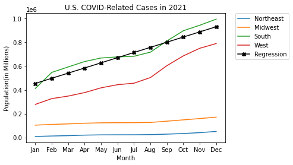

```python
X = df[['submission_date', 'people_vaccinated', 'tot_death']]
y = df['tot_cases'].tolist()
y_reg = []

res = stats.linregress(lst, y)
print(res)

plt.title('U.S. COVID-Related Cases in 2021')
plt.xlabel("Month")
plt.ylabel("Population(in Millions)")
for c in range(0,12):
    y_reg.append(res.intercept + res.slope * c)

plt.plot(months, ne_cases, label='Northeast')
plt.plot(months, mw_cases, label='Midwest')
plt.plot(months, so_cases, label='South')
plt.plot(months, we_cases, label='West')

plt.plot(months, y_reg, color='k', marker='X', label='Regression')
plt.legend(bbox_to_anchor=(1.05, 1), loc='upper left', borderaxespad=0.)
```

The linear regression line shows that the total number of cases seem to increase by around 43357 cases globally. However, as you can see in relation to each different Region, that is is only a national view. After looking at each region, we can see how the estimate fits in relation to them.

## Northeastern Comparison

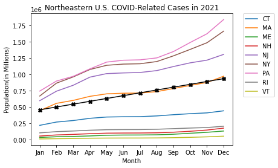

```python
#Total number of reported cases in Northeast with Regression Line
plt.title('Northeastern U.S. COVID-Related Cases in 2021')
plt.xlabel("Month")
plt.ylabel("Population(in Millions)")
for x in state_results:
    if x[0] in northeast:
        plt.plot(months, x[1]['tot_cases'], label=x[0])
plt.legend(bbox_to_anchor=(1.05, 1), loc='upper left', borderaxespad=0.)
plt.autoscale(enable=True, axis='both')
plt.plot(months, y_reg, color='k', marker='X')
```

## Midwestern Comparison

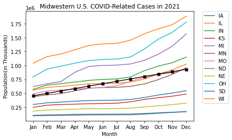

```python
#Total number of reported cases in Midwest with Regression Line
plt.title('Midwestern U.S. COVID-Related Cases in 2021')
plt.xlabel("Month")
plt.ylabel("Population(in Thousands)")
for x in state_results:
    if x[0] in midwest:
        plt.plot(months, x[1]['tot_cases'], label=x[0])
plt.legend(bbox_to_anchor=(1.05, 1), loc='upper left', borderaxespad=0.)
plt.autoscale(enable=True, axis='both')
plt.plot(months, y_reg, color='k', marker='X')
```

## Southern Comparison

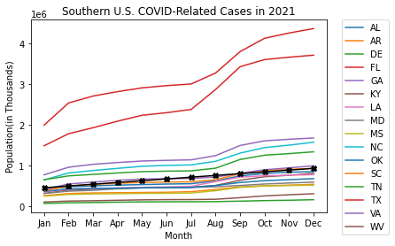

```python
#Total number of reported cases in South with Regression Line
plt.title('Southern U.S. COVID-Related Cases in 2021')
plt.xlabel("Month")
plt.ylabel("Population(in Thousands)")
for x in state_results:
    if x[0] in south:
        plt.plot(months, x[1]['tot_cases'], label=x[0])
plt.legend(bbox_to_anchor=(1.05, 1), loc='upper left', borderaxespad=0.)
plt.autoscale(enable=True, axis='both')
plt.plot(months, y_reg, color='k', marker='X')
```

## Western Comparison

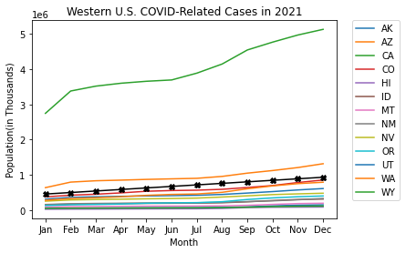

```python
#Total number of reported cases in West with Regression Line
plt.title('Western U.S. COVID-Related Cases in 2021')
plt.xlabel("Month")
plt.ylabel("Population(in Thousands)")
for x in state_results:
    if x[0] in west:
        plt.plot(months, x[1]['tot_cases'], label=x[0])
plt.legend(bbox_to_anchor=(1.05, 1), loc='upper left', borderaxespad=0.)
plt.autoscale(enable=True, axis='both')
plt.plot(months, y_reg, color='k', marker='X')
```

## Extra Analysis

One of the biggest issue with the Vaccination rate is the fact that eligibilty for vaccination initially centered around age, in descending order. That meant those older would get their vaccinations before children. This poses a potential cause, since children are typically in a more crowded environment than adults. Regardless of quarantine, we should look at the larger causes of the rise in cases. Since children were able to be vaccinated after May 2021, we can look before and after. Therefore, the first five months could infer a relationship with the trend.

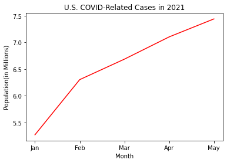

```python
#Total number of cases in the US
plt.title('U.S. COVID-Related Cases in 2021')
plt.xlabel("Month")
plt.ylabel("Population(in Millions)")

#Ages 0-18 make up 23.6% of the population
new_data = []
temp = cases_over_time[0:5]
for x in temp:
    new_data.append(x*.236)
new_data

plt.plot(months[0:5], new_data, color='red')
```

# Conclusion

Hopefully this project has not only served to inform you of the importance of immunization, but allowed you to understand the Data Science Cycle, and the potential it displays for the future.